# Writeup

Ck

March 2, 2019

# Introduction

Using devices such as Jawbone Up, Nike FuelBand, and Fitbit it is now possible to collect a large amount of data about personal activity relatively inexpensively. These type of devices are part of the quantified self movement - a group of enthusiasts who take measurements about themselves regularly to improve their health, to find patterns in their behavior, or because they are tech geeks. One thing that people regularly do is quantify how much of a particular activity they do, but they rarely quantify how well they do it.

In this project, our goal will be to use data from accelerometers on the belt, forearm, arm, and dumbell of 6 participants. They were asked to perform barbell lifts correctly and incorrectly in 5 different ways.

# Data set

The training data for this project are available here:

https://d396qusza40orc.cloudfront.net/predmachlearn/pml-training.csv

The test data are available here:

https://d396qusza40orc.cloudfront.net/predmachlearn/pml-testing.csv

# Data Cleaning

Now we will do data partition(75% and 25%)

```r
in_train<-createDataPartition(training$classe, p=0.75, list=FALSE)
train_set<-training[in_train,]
test_set<-training[-in_train,]

dim(train_set)
```

```
## [1] 14718   160
```

```r
dim(test_set)
```

```
## [1] 4904  160
```

Clean test and training data from near-zero-variance values and NAs

```r
nzv<-nearZeroVar(train_set)
train_set<-train_set[,-nzv]
test_set<-test_set[,-nzv]

nas<-sapply(train_set, function(x) mean(is.na(x))) >0.95
train_set<-train_set[,nas==FALSE]
test_set<-test_set[,nas==FALSE]
```

column 1-5 can be removed as they are just id variables.

```r
train_set<-train_set[,-(1:5)]
test_set<-test_set[,-(1:5)]

dim(train_set)
```

```
## [1] 14718    54
```

```r
dim(test_set)
```

```
## [1] 4904   54
```

# Prediction Models

## 1. Decision Tree Model

[figure not shown]

```r
set.seed(1813)
dec_tree<-rpart(classe~., data=train_set, method="class")
fancyRpartPlot(dec_tree)
```

Predictions on test_set

```r
predict_decision_tree<-predict(dec_tree, newdata=test_set, type="class")
conf_matrix<-confusionMatrix(predict_decision_tree, test_set$classe)
conf_matrix
```

```
## Confusion Matrix and Statistics
##
##           Reference
## Prediction    A    B    C    D    E
##          A 1248  173   48   42   39
##          B   49  589   29   92   40
##          C    3   54  667  107   49
##          D   76   89   51  494   98
##          E   19   44   60   69  675
##
## Overall Statistics
##
##                Accuracy : 0.749
##                  95% CI : (0.7366, 0.7611)
##     No Information Rate : 0.2845
##     P-Value [Acc > NIR] : < 2.2e-16
##
##                   Kappa : 0.6814
##  Mcnemar's Test P-Value : < 2.2e-16
##
## Statistics by Class:
##
##                      Class: A Class: B Class: C Class: D Class: E
## Sensitivity            0.8946   0.6207   0.7801   0.6144   0.7492
## Specificity            0.9139   0.9469   0.9474   0.9234   0.9520
## Pos Pred Value         0.8052   0.7372   0.7580   0.6114   0.7785
## Neg Pred Value         0.9562   0.9123   0.9533   0.9243   0.9440
## Prevalence             0.2845   0.1935   0.1743   0.1639   0.1837
## Detection Rate         0.2545   0.1201   0.1360   0.1007   0.1376
## Detection Prevalence   0.3161   0.1629   0.1794   0.1648   0.1768
## Balanced Accuracy      0.9043   0.7838   0.8638   0.7689   0.8506
```

Plot predictive accuracy of decision tree model

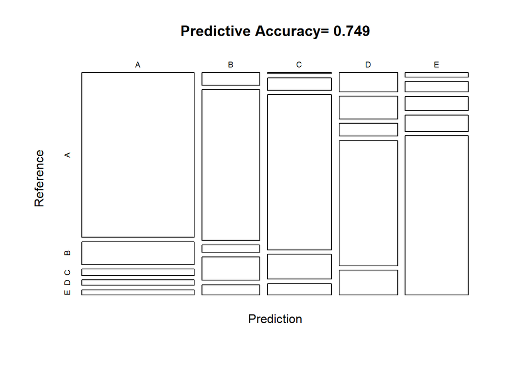

```r
plot(conf_matrix$table, col=conf_matrix$byClass, main=paste("Predictive Accuracy=", round(conf_matrix$overall['Accuracy'],4)))
```

## 2. Random Forest Model

```r
control_rf<-trainControl(method="repeatedcv", number = 5, repeats = 2)
fit_rf<-train(classe~., data=train_set, method="rf", trControl=control_rf, tuneLength=1, verbose=FALSE)
fit_rf$finalModel
```

```
##
## Call:
##  randomForest(x = x, y = y, mtry = param$mtry, verbose = FALSE)
##                Type of random forest: classification
##                      Number of trees: 500
## No. of variables tried at each split: 17
##
##         OOB estimate of  error rate: 0.2%
## Confusion matrix:
##      A    B    C    D    E class.error
## A 4185    0    0    0    0 0.000000000
## B    5 2841    2    0    0 0.002457865
## C    0    4 2563    0    0 0.001558239
## D    0    0   10 2401    1 0.004560531
## E    0    0    0    8 2698 0.002956393
```

Prediction on test_set

```r
predict_rf<-predict(fit_rf, newdata=test_set)
conf_matrix_rf<-confusionMatrix(predict_rf, test_set$classe)
conf_matrix_rf
```

```
## Confusion Matrix and Statistics
##
##           Reference
## Prediction    A    B    C    D    E
##          A 1394    1    0    0    0
##          B    0  947    4    0    0
##          C    0    1  851    5    0
##          D    0    0    0  799    1
##          E    1    0    0    0  900
##
## Overall Statistics
##
##                Accuracy : 0.9973
##                  95% CI : (0.9955, 0.9986)
##     No Information Rate : 0.2845
##     P-Value [Acc > NIR] : < 2.2e-16
##
##                   Kappa : 0.9966
##  Mcnemar's Test P-Value : NA
##
## Statistics by Class:
##
##                      Class: A Class: B Class: C Class: D Class: E
## Sensitivity            0.9993   0.9979   0.9953   0.9938   0.9989
## Specificity            0.9997   0.9990   0.9985   0.9998   0.9998
## Pos Pred Value         0.9993   0.9958   0.9930   0.9988   0.9989
## Neg Pred Value         0.9997   0.9995   0.9990   0.9988   0.9998
## Prevalence             0.2845   0.1935   0.1743   0.1639   0.1837
## Detection Rate         0.2843   0.1931   0.1735   0.1629   0.1835
## Detection Prevalence   0.2845   0.1939   0.1748   0.1631   0.1837
## Balanced Accuracy      0.9995   0.9984   0.9969   0.9968   0.9993
```

# Conclusion

From above matrix, we can say that Random Forest model is very accurate with accuracy of about 99%.